# Geographic Coverage Accross Central Valley System According to Lindley et al. and Yoshiyama et al. Overview

2024-03-14

## Introduction

The ecosystem management process in the Central Valley faces significant challenges due to the slow and complex nature of integrating flow, habitat, and temperature data. This project aims to address these challenges by compiling interoperable flow datasets to enhance ecosystem management evaluations, with a particular focus on areas in the Central Valley that are currently utilized, or have potential for salmonid use. This document provides an overview of the geographical coverage included in our ‘system of interest.’ By referencing two scientific papers, [Yoshiyama et al.](https://nrm.dfg.ca.gov/FileHandler.ashx?DocumentID=3563) and [Lindley et al.](https://swfsc-publications.fisheries.noaa.gov/publications/CR/2006/2006Lin.pdf), we will compare the geographical coverage differences between the streams examined in each study.

## [Yoshiyama et al.](https://nrm.dfg.ca.gov/FileHandler.ashx?DocumentID=3563)

In order to comprehensively assess the historical significance of salmon in the regional landscape, Yoshiyama et al. consolidate historical and current data on the distribution of Chinook salmon in the major streams of the Central Valley. They build upon previous research and expand earlier work to include additional historical information and recent data on Chinook salmon abundances as follows:

- Determine the geographic extent for each major stream through a review of literature and unpublished documents.
- Establish probable historical distributions by considering the presence of natural barriers to upstream salmon migration and historical accounts, such as those from gold miners and early settlers.
- Gather additional insights through ethnographic studies conducted during the early 20th century. These studies involved interviews with elder Native Americans from various tribal groups, offering valuable information on the material culture and traditions of California’s native peoples.

## [Lindley et al.](https://swfsc-publications.fisheries.noaa.gov/publications/CR/2006/2006Lin.pdf)

Lindley et al. focuse on understanding the historical population structure of Central Valley steelhead to aid in effective conservation and recovery planning. They establish the description of the historical structure of the Central Valley steelhead evolutionary significant unit (ESU) using a multi-phase modeling approach as follows:

- In the first phase, they develop a habitat model based on environmental factors such as stream discharge, gradient, and temperature, incorporating data from digital elevation models and climate data. This initial phase identifies 151 patches of potentially suitable habitat.
- Subsequently, they measure the distances among these habitat patches, and cluster patches within 35 km of each other, resulting in 81 distinct habitat patches.
- They analyze climate and elevation differences among these 81 habitat areas, revealing at least four major subdivisions within the Central Valley steelhead ESU. These subdivisions correspond to specific geographic regions, including the Sacramento River basin, Suisun Bay area tributaries, San Joaquin tributaries draining the Sierra Nevada, and lower-elevation streams draining to the Buena Vista and Tulare basins, upstream of the San Joaquin River.

# Plot showing a comparison of literature stream coverage

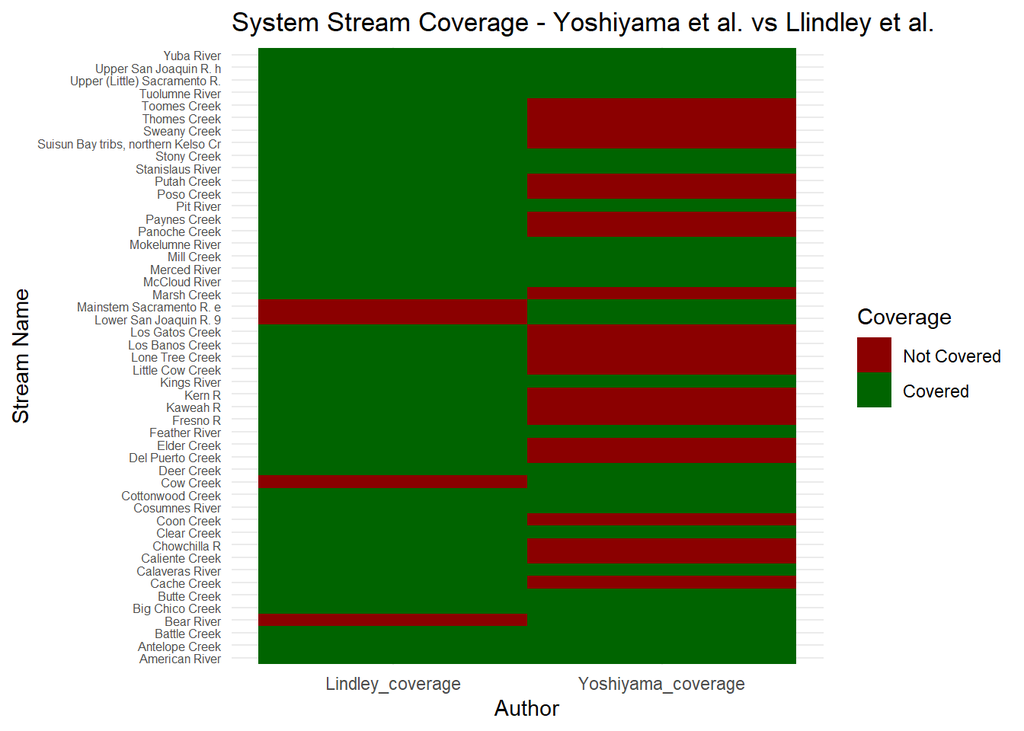

# Table compring system coverage definitions of Yoshiyama et al. vs Lindley et al.

| stream name | Yoshiyama | Lindley |
| --- | --- | --- |
| American River | **yes** | **yes** |
| Antelope Creek | **yes** | **yes** |
| Battle Creek | **yes** | **yes** |
| Bear River | **yes** | **no** |
| Big Chico Creek | **yes** | **yes** |
| Butte Creek | **yes** | **yes** |
| Cache Creek | **no** | **yes** |
| Calaveras River | **yes** | **yes** |
| Caliente Creek | **no** | **yes** |
| Chowchilla River | **no** | **yes** |
| Clear Creek | **yes** | **yes** |
| Coon Creek | **no** | **yes** |
| Cosumnes River | **yes** | **yes** |
| Cottonwood Creek | **yes** | **yes** |
| Cow Creek | **yes** | **no** |
| Deer Creek | **yes** | **yes** |
| Del Puerto Creek | **no** | **yes** |
| Elder Creek | **no** | **yes** |
| Feather River | **yes** | **yes** |
| Fresno River | **no** | **yes** |
| Kaweah River | **no** | **yes** |
| Kern River | **no** | **yes** |
| Kings River | **yes** | **yes** |
| Little Cow Creek | **no** | **yes** |
| Lone Tree Creek | **no** | **yes** |
| Los Banos Creek | **no** | **yes** |
| Los Gatos Creek | **no** | **yes** |
| Marsh Creek | **no** | **yes** |
| McCloud River | **yes** | **yes** |
| Merced River | **yes** | **yes** |
| Mill Creek | **yes** | **yes** |
| Mokelumne River | **yes** | **yes** |
| Panoche Creek | **no** | **yes** |
| Paynes Creek | **no** | **yes** |
| Pit River | **yes** | **yes** |
| Poso Creek | **no** | **yes** |
| Putah Creek | **no** | **yes** |
| Stanislaus River | **yes** | **yes** |
| Stony Creek | **yes** | **yes** |
| Northern Kelso Creek | **no** | **yes** |
| Sweany Creek | **no** | **yes** |
| Thomes Creek | **no** | **yes** |
| Toomes Creek | **no** | **yes** |
| Tuolumne River | **yes** | **yes** |
| Upr Sacramento River | **yes** | **yes** |
| Mainstem Sacramento River | **yes** | **no** |
| Upper San Joaquin Rriver | **yes** | **yes** |
| Lower San Joaquin River | **yes** | **no** |
| Westside Streams | **yes** | **no** |
| Yuba River | **yes** | **yes** |